# Daños y vulnerabilidad de estructuras laminares bajo acciones extremas en infraestructura de almacenamiento y proceso

## Variables cualitativas para ACM

Buscamos identificar asociaciones entre las categorías y detectar grupos de individuos con perfiles similares.

Puesto que la zona sismica determina el riesgo sísmico, se descarta `zona_sismica` y ya que el viento de diseño fue considerado en el ACP se descarta `ciudad_cerca_viento.`

A su vez, buscamos observar posibles asociasiones de tanques independientemente de la `empresa` que lo opera para enfocarnos a caracteristicas estructurales.

Ejecutar el ACM

Varianza explicada

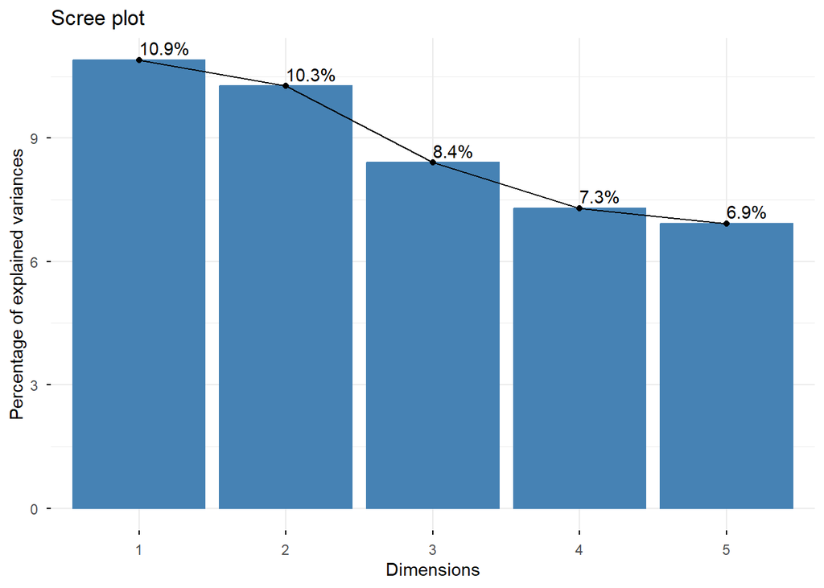

Mapa de categorías

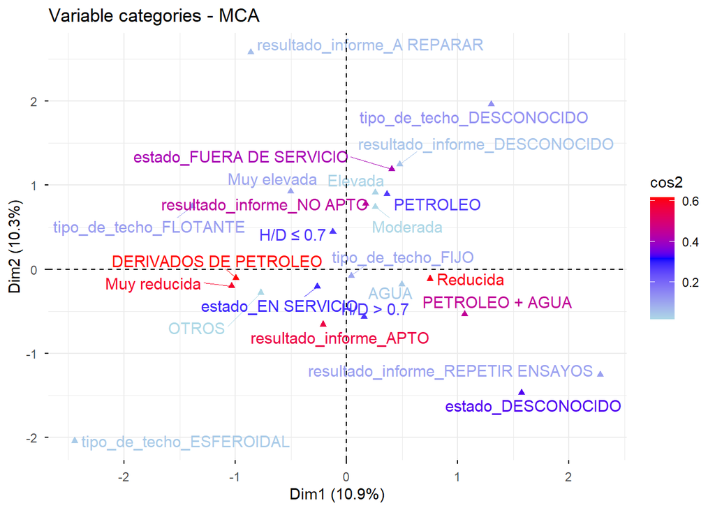

La proximidad observada entre las categorías “Derivados de petroleo”, “En servicio”, “Informe Apto” y niveles riesgo de riesgo sísmico indica que estas características tienden a aparecer asociadas con mayor frecuencia dentro de la base analizada. Sin embargo, esta asociación no debe interpretarse como una relación causal. El ACM permite identificar patrones de coexistencia entre categorías, pero no establecer mecanismos causa-efecto entre ellas.

Por lo tanto, únicamente puede afirmarse que dichas características aparecen relacionadas dentro de la muestra estudiada.

Una posible interpretación es que tanques que almacenan derivados de petróleo pueden estar sometidos a rutinas de mantenimiento más frecuentes y que se concentran en zonas costeras donde el riesgo sismico para Argentina es menor.

**Contribuciones de las categorias en las dimensiones 1:**

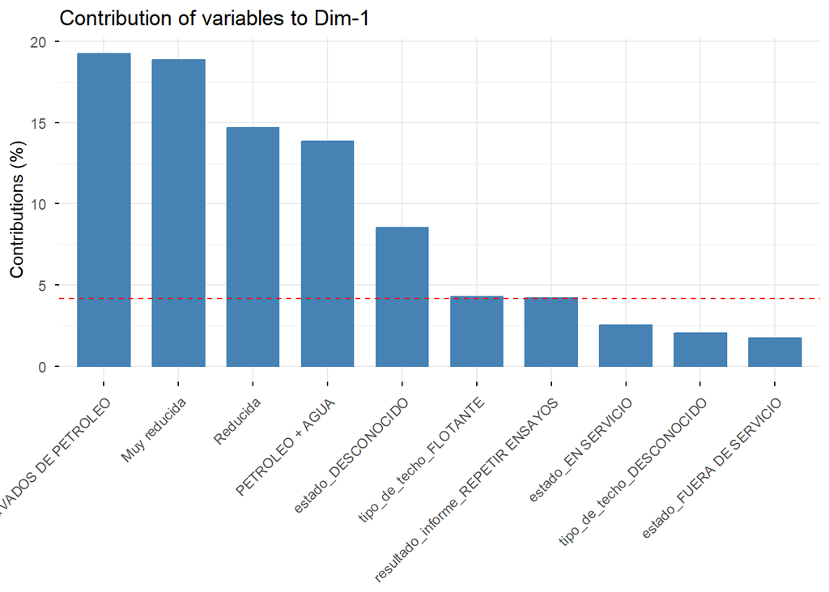

**Contribuciones de las categorias en las dimensiones 2:**

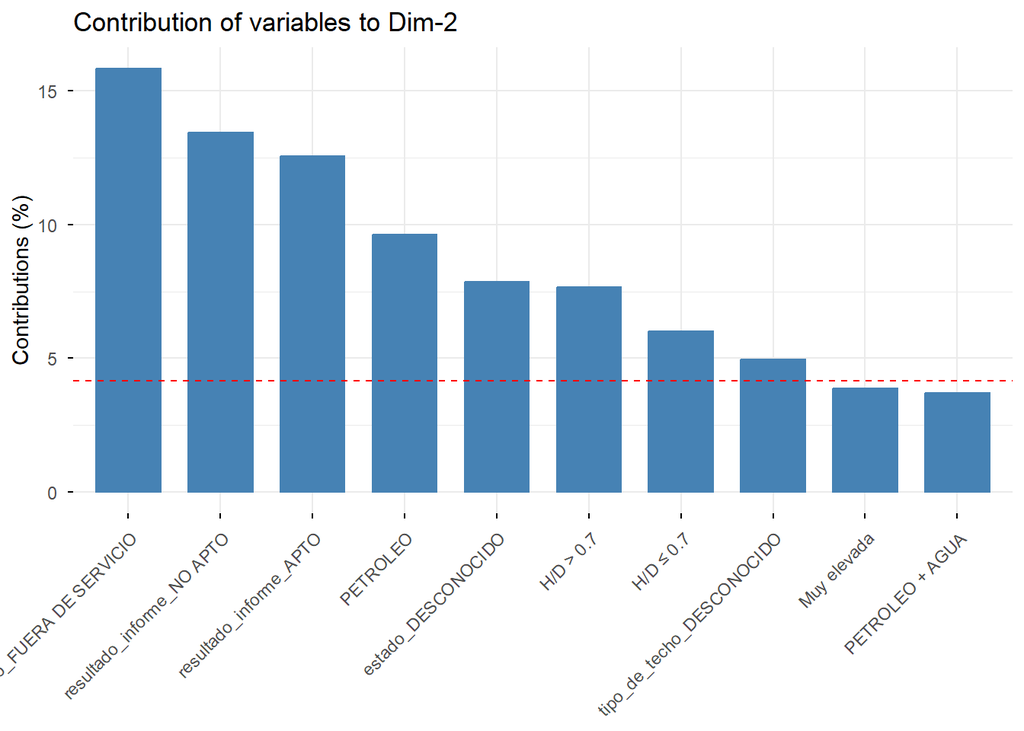

El Análisis de Correspondencias Múltiples permitie identificar dos estructuras principales en los datos. La primera dimensión esta dominada por las categorías de tipo de producto y de riesgo sísmico, separando emplazamientos de baja peligrosidad de aquellos asociados a mayores niveles de amenaza sísmica. La segunda dimensión esta relacionada principalmente con el estado operativo y el resultado de las inspecciones, diferenciando tanques aptos y en servicio de aquellos clasificados como no aptos o fuera de servicio. Asimismo, se observa una proximidad entre las categorías “No apto”, “Fuera de servicio” y niveles elevados de riesgo sísmico, sugiriendo una asociación entre estas características dentro de la población analizada.

## Análisis de clustering y evaluación de influencia

Con el propósito de identificar perfiles de tanques con características similares y explorar posibles patrones asociados, se propone desarrollar un análisis de clustering considerando las características geométricas, constructivas y operativas de los tanques relevados, es decir, todas las variables cuantitativas y cualitativas relevadas.

En particular, se evaluará la influencia de la variable `viento_cat_III_ms`, que representa la velocidad básica de viento de referencia establecida por el reglamento CIRSOC 102-2025, asignada a cada tanque según la ciudad geográficamente más cercana a su emplazamiento.

Como alternativa se evaluará nuevamente la influencia de la variable `riesgo_sismico,` considerando todas las variables a diferencia del ACP, y finalmente se evaluará la influencia de la variable `clase_esbeltez,` que mostró ciertas asociaciones en el análisis del ACP y que representa un límite de riesgo por efectos de pandeo y colapso de las bases de los tanques.

**Modelo A1: clustering sin inclusión de variables extras**

Se realizará un primer análisis excluyendo cualquier variable extra de influencia, manteniendo las restantes características. El objetivo será identificar perfiles constructivos y operativos sin incorporar explícitamente la condición asociadas a otras referencias, que serviran de base.

**Modelo A2: clustering con inclusión de la variable de viento.**

Se incorporará la velocidad básica de viento como variable cuantitativa, junto con las características geométricas, constructivas y operativas de los tanques. Este modelo permitirá identificar perfiles que contemplen tanto las particularidades de cada estructura como las condiciones geográficas de diseño desde el punto de vista de vientos.

**Modelo A3: clustering con inclusión de la variable de sismo.**

Se incorporará el riesgo sísmico como variable cualitativa, junto con las características geométricas, constructivas y operativas de los tanques. Este modelo permitirá identificar perfiles que contemplen tanto las particularidades de cada estructura como las condiciones geográficas de diseño desde el punto de vista sísmica.

**Modelo A4: clustering con inclusión de la variable límite de esbeltez**

Puesto que el valor de esbeltez 0.7 representa un límite caracteristico para el riesgo de pandeo, efectos sísmicos de viento a las estructuras se lo utilizara como cuarto modelo.

En todos modelos se utilizarán procedimientos de clustering para datos mixtos y se evaluará la calidad de las agrupaciones mediante índices de validación, particularmente el coeficiente Silhouette. Asimismo, se analizará la composición y estabilidad de los grupos obtenidos.

Finalmente, se compararán los resultados para determinar en qué medida la incorporación de la variable de extra modifica la conformación de los conglomerados. Esta comparación permitirá evaluar la influencia de las condiciones geográficas de diseño ó geométricas en la identificación de perfiles de tanques.

## Distancia de Gower

La **distancia de Gower** es una medida de disimilitud diseñada para trabajar con bases de datos que contienen simultáneamente variables cuantitativas y cualitativas. En el trabajo fue utilizada porque los tanques están descritos mediante variables numéricas (volumen, diámetro, altura, espesor, velocidad de viento) y variables categóricas (estado, producto, tipo de techo).

Para cada par de tanques, Gower calcula una distancia parcial en cada variable:

- Para variables numéricas utiliza la diferencia entre valores, normalizada por el rango de la variable.
- Para variables categóricas asigna 0 si las categorías coinciden y 1 si son diferentes.

Luego promedia todas las distancias parciales obteniendo un valor entre:

$0≤d≤1$

donde:

- 0 significa que los tanques son muy similares.
- 1 significa que son completamente diferentes.

Se compara de 2 a 6 grupos utilizando PAM (Partition Around Medoids)

Una vez calculadas las distancias de Gower, se aplicó el algoritmo **PAM (Partition Around Medoids)** para identificar grupos de tanques con características similares.

El objetivo de PAM es dividir los datos en **k conglomerados** de forma que los tanques dentro de un mismo grupo sean lo más parecidos posible y los tanques de grupos distintos sean lo más diferentes posible.

A diferencia de k-means:

| K-means | PAM |
| --- | --- |
| Usa centroides (promedios) | Usa medoids (observaciones reales) |
| Requiere distancia euclídea | Puede usar cualquier distancia |
| Más sensible a outliers | Más robusto a outliers |

## Comparación índice Silhouette

El coeficiente de Silhouette es una medida que se utiliza para evaluar la calidad de un agrupamiento (clustering). Indica qué tan bien asignada está cada observación a su grupo y qué tan separada está de los demás grupos

| Silhouette | Interpretación |
| --- | --- |
| Cerca de 1 | Muy bien agrupado |
| 0.5 - 0.7 | Buena separación |
| 0.25 - 0.5 | Agrupamiento débil-moderado |
| < 0.25 | Agrupamiento débil |
| Negativo | Probablemente mal asignado |

## Indices de silhouette

**Modelo A1**

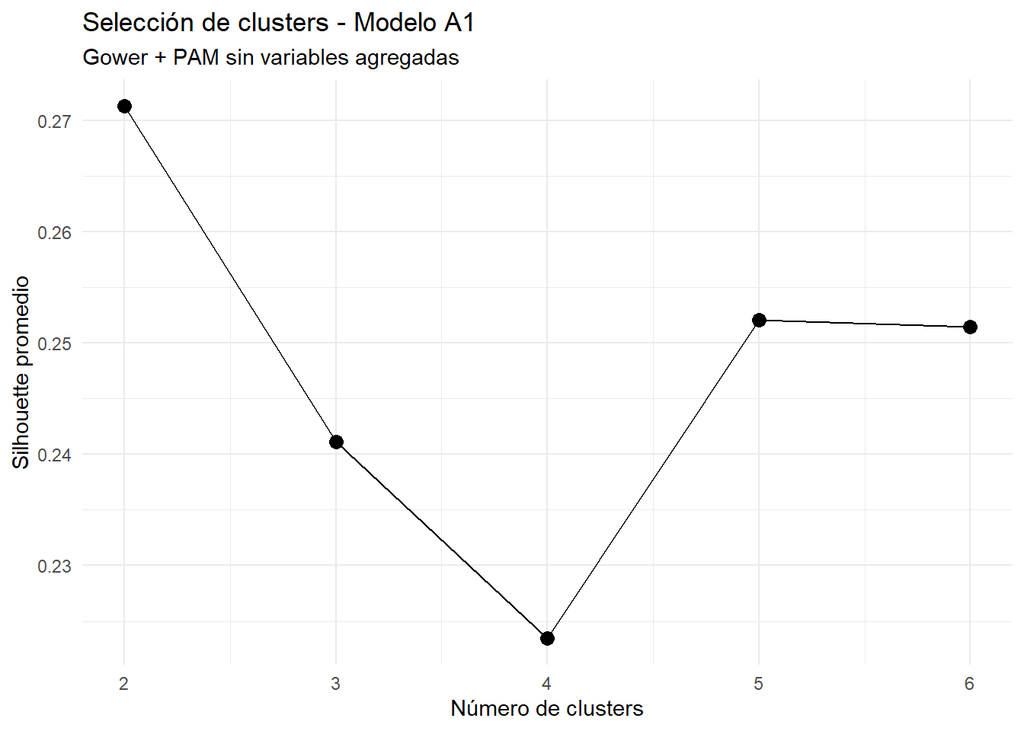

Respecto al modelo A1, La solución de dos grupos presenta el mejor resultado y al pasar de dos a tres clusters, la calidad de agrupación cae considerablemente. A partir de cuatro grupos hay una recuperación gradual, pero no se alcanza el valor inicial. Esto sugiere que dividir los datos en tres o más grupos produce conglomerados menos cohesionados o menos diferenciados. Al no tener variables incorporadas como influencia se toma como referencia y son los valores que se pretende mejorar en los demas modelos

**Modelo A2**

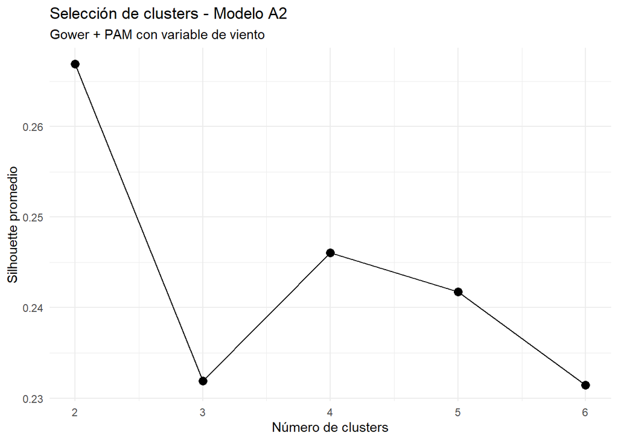

Es interesante que, al excluir la variable de viento, la solución de seis grupos mejora respecto de las alternativas intermedias, aunque sigue siendo inferior a k = 2.

**Modelo A3**

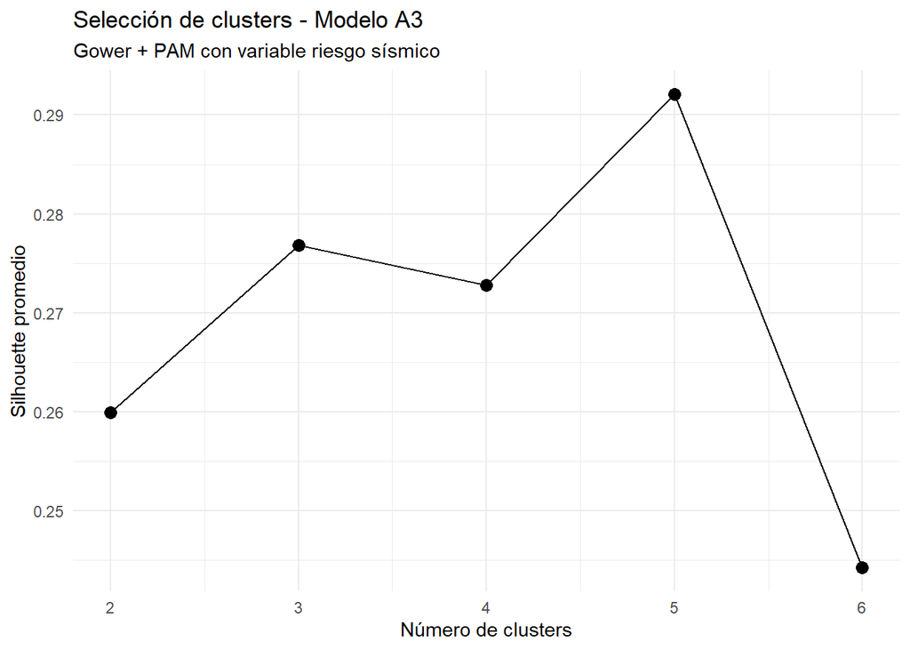

Al considerar el modelo A3, se observa que la mejor agrupación se logra al considerar 5 clusters y que el índice de silhouette mejora respecto al modelo base y al modelo que clasifica según vientos.

Esto tiene cierta consistencia en que existen 5 zonas sísmicas, sin embargo deberíamos justificar aún como caracterizar geometricamente 5 perfiles de tanques lo cual no tienen sustento práctico.

**Modelo A4**

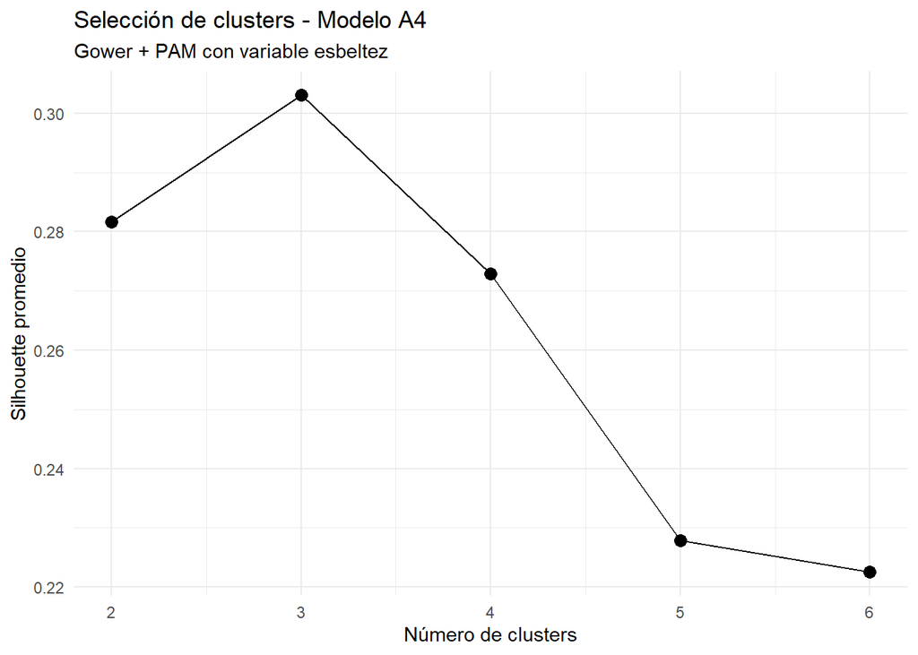

Finalmente, el modelo A4 presenta el mejor indice de silhouette para una agrupación de 3 clusters con un valor cercano al 0,31. Esto da indicios que los tanques según su esbeltez, tamaño y geometría podrían agruparse en 3 grupos con caracteristicas similares.

Sin embargo, no podemos afirmar todavía que la esbeltez crítica tenga una influencia importante en la conformación de los grupos.

Es decir, esto significa que debemos evitar presentar los conglomerados como perfiles claramente diferenciados.

Ajustamos los modelos 1 como referncia para los otros modelos y el modelo 2 a k=2, el modelo 3 a k=6 y el modelo 4 a k=3

Se observan diferencias en la composición de los clusters cuando la variable en cuestión está presente. A continuación analizaremos la relevancia de dicha diferencia.

```
   A2
A1    1   2
  1 104   7
  2   4 136
```

```
[1] 0.8316886
```

```
   A3
A1   1  2  3  4  5  6
  1 24  1  4  2  0  1
  2  0 47  2  1  3  7
  3  0 15  5  3  0  0
  4  5 12 13  2  0  0
  5  0  2  0  0 40 16
  6  0  4  0 40  0  2
```

```
[1] 0.4554946
```

```
   A4
A1   1  2  3
  1 54  6  1
  2  3 44 54
  3  2 54 33
```

```
[1] 0.2870508
```

El Adjusted Rand Index (ARI) mide la similitud entre dos particiones, ajustando la coincidencia esperada por azar. El ARI toma valores entre -1 y 1:

| Valor ARI | Interpretación |
| --- | --- |
| 1 | Las particiones son idénticas |
| ≈ 0 | La concordancia es similar a la esperada por azar |
| < 0 | Menor coincidencia que la esperada por azar |
| 0.4 - 0.6 | Concordancia moderada |
| > 0.8 | Concordancia muy alta |

   Una posible interpretación es que la variable de esbeltez crítica introduce información que modifica algunos perfiles, pero no transforma completamente la estructura general de los grupos, en tanques diferenciados por su volumen, su geometria y su esbeltez.

## Caracterizamos los clusters

## Clusters Modelos con influencia

**Clusters Modelo A2**

```
# A tibble: 2 × 8
  cluster_A2     n volumen altura diametro virolas espesor esbeltez
  <fct>      <int>   <dbl>  <dbl>    <dbl>   <dbl>   <dbl>    <dbl>
1 1            108   3000    11.8     20.0       7    9.53    0.518
2 2            143   1474.   11       13         6    7.92    0.748
```

**Clusters Modelo A3**

```
# A tibble: 6 × 8
  cluster_A3     n volumen altura diametro virolas espesor esbeltez
  <fct>      <int>   <dbl>  <dbl>    <dbl>   <dbl>   <dbl>    <dbl>
1 1             29    3500   12       21.4       8    9.60    0.479
2 2             81    3016   12       18.3       7    9.53    0.632
3 3             24   14000   11.9     42.2       7   19.0     0.323
4 4             48    1550   10.5     14.8       6    6.88    0.668
5 5             43    1000   10       10.6       5    6.35    1.05
6 6             26    1000    9       13.1       5    6.35    0.714
```

**Clusters Modelo A4**

```
# A tibble: 3 × 8
  cluster_A4     n volumen altura diametro virolas espesor esbeltez
  <fct>      <int>   <dbl>  <dbl>    <dbl>   <dbl>   <dbl>    <dbl>
1 1             59    5000   11.8     24.8       7    9.67    0.458
2 2            104    1000   12.0     10.9       6    6.82    0.924
3 3             88    3180   10.5     21         6    9.53    0.479
```

## Comparación gráfica para el modelo A4 (esbeltez crítica)

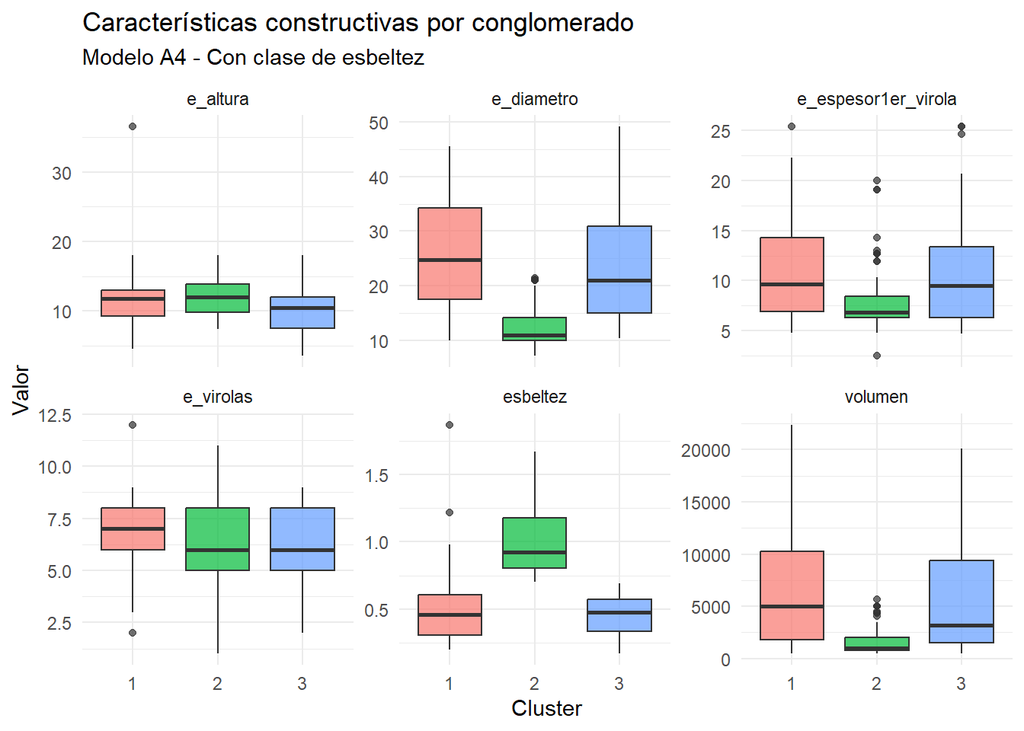

## Grafica de los clusters modelo A4

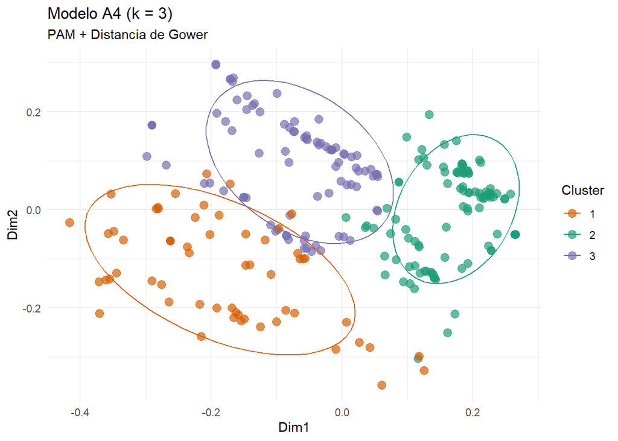

Se observa que el modelos A4 están identificando esencialmente tres perfiles constructivos de tanques:

1. Tanques de grandes volumenes.

Corresponde a tanques de gran volumen y baja esbeltez. Son estructuras de gran diámetro, típicas de refinerías, terminales de almacenamiento y grandes instalaciones de proceso. Debido al elevado inventario almacenado, una eventual falla estructural puede generar consecuencias operativas y ambientales significativas.

2. Tanques esbeltos de volumen moderados a bajos.

Corresponde a tanques de bajo volumen y elevada esbeltez. Desde el punto de vista estructural representan el perfil más vulnerable frente a fenómenos de inestabilidad, ya que presentan relaciones H/D cercanas o superiores al límite de referencia de 0,7 identificado en la bibliografía sobre daño sísmico.

3. Tanques no esbeltos de volumenes moderados a bajos.

Corresponde a tanques de volumen moderado y baja esbeltez. Constituyen una situación intermedia entre los grandes tanques de almacenamiento y los tanques esbeltos de menor capacidad. Presentan configuraciones geométricas relativamente robustas y representan una parte importante de las instalaciones analizadas.

### Conclusiones sobre modelo de clusters

Con el propósito de evaluar la influencia de las condiciones de exposición al climáticas y geológicas en la conformación de estos perfiles, se compararon dos modelos: uno que incorporó la velocidad básica de viento de referencia establecida por el CIRSOC 102-2025 y otro que incorporó el riesgo sismico segun CIRSOC 103-2018.

En cuanto a la calidad del agrupamiento, el modelo que incorporó la variable esbeltez obtuvo un coeficiente Silhouette de 0,31, frente a 0,275 del modelo base. Esta diferencia representa una mejora leve, por lo que no puede considerarse que la incorporación de dicha variable produzca una mejora sustancial en la separación de los grupos, sino solo una referencia.

En consecuencia, los resultados sugieren que las características geométricas y constructivas constituyen los principales elementos diferenciadores de los perfiles identificados. La variable esbeltez aporta información adicional que modifica parcialmente la asignación de las observaciones, aunque no altera la estructura general de los perfiles de manera significativa.

Finalmente, los conglomerados obtenidos deben interpretarse como una clasificación exploratoria de los tanques, útil para reconocer tipologías constructivas y analizar semejanzas entre sus características, sin que ello implique una separación estadística fuerte entre los grupos.

# **6 - CONCLUSIONES GENERALES**

## ¿Cómo pueden caracterizarse los tanques incluidos en la base de datos desde el punto de vista de dimensiones, tipos de techo, ubicación, fluido?

Los tanques analizados pueden agruparse principalmente según su capacidad de almacenamiento, geometría y esbeltez. Predominan los tanques de techo fijo, utilizados para almacenamiento de petróleo, mezclas de petróleo y agua, combustibles y agua de formación. Desde el punto de vista estructural se identificaron tres perfiles principales:

1. Tanques de grandes volumenes (media=5000 metros cúbicos) y esbeltez baja (media=0.47) .
2. Tanques esbeltos de bajo volumen (media=1000 metros cúbicos) y esbeltez alta (media=0.92) .
3. Tanques no esbeltos de volumenes moderados a bajos. (media=3000 metros cúbicos) y esbeltez baja (media=0.47) .

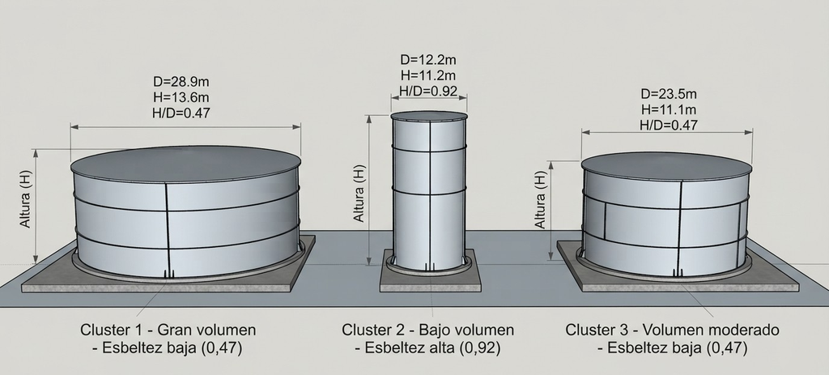

Clasificación propuesta de tanques

## ¿Es posible obtener alguna caracterización de los riesgos mas frecuentes?

Sí, los riesgos identificados surgen de la combinación entre condiciones geográficas y vulnerabilidad estructural. Desde el punto de vista geográfico, una parte significativa de los tanques se encuentra expuesta a condiciones de riesgo sísmico y viento relevantes. Desde el punto de vista estructural, la geometría de los tanques, particularmente la esbeltez, aparece como una característica importante para la identificación de perfiles potencialmente más vulnerables frente a acciones extremas.

[interactive chart not shown]